# JHUShiny Presentation

cybersuno

20/2/2021

# Purpose

The objective of this presentation is to show the shiny application developed as part of the Johns Hopkins University week 4 for the *Developing Data Products* course.

The purpose of the application is to show the linear regression between the different variables in the mtcars dataset. For this, two variables are selected and a linear model (lm) is fitted. The application shows the coefficients for the linear model and a plot with the two variables and the correlation.

The *mtcars* dataset has the following structure

```
## 'data.frame':    32 obs. of  11 variables:
##  $ mpg : num  21 21 22.8 21.4 18.7 18.1 14.3 24.4 22.8 19.2 ...
##  $ cyl : num  6 6 4 6 8 6 8 4 4 6 ...
##  $ disp: num  160 160 108 258 360 ...
##  $ hp  : num  110 110 93 110 175 105 245 62 95 123 ...
##  $ drat: num  3.9 3.9 3.85 3.08 3.15 2.76 3.21 3.69 3.92 3.92 ...
##  $ wt  : num  2.62 2.88 2.32 3.21 3.44 ...
##  $ qsec: num  16.5 17 18.6 19.4 17 ...
##  $ vs  : num  0 0 1 1 0 1 0 1 1 1 ...
##  $ am  : num  1 1 1 0 0 0 0 0 0 0 ...
##  $ gear: num  4 4 4 3 3 3 3 4 4 4 ...
##  $ carb: num  4 4 1 1 2 1 4 2 2 4 ...
```

# Application Input

The application requires two variables:

- Y var: this is the variable to be in the Y axis, and the variable to be estimated
- X var: this is the variable to be in the X axis, and the predictor in the model

The model is fitted with the following formula: Y ~ X

We can build an example for the variables:

- Y = mpg
- X = disp

```r
fit<-lm(mpg ~ disp,data=mtcars)
```

# Application Output: coefficients

The output is divided in two elements: coefficients for the model and plot with the regression

The coefficients are:

- Intercept
- Slope for the predictor

Each line have four entries. The information is the same as when the model is summarized:

- The value
- The standard error
- T value
- p-value

In our example, information showed could be:

```
##                Estimate  Std. Error   t value     Pr(>|t|)
## (Intercept) 29.59985476 1.229719515 24.070411 3.576586e-21
## disp        -0.04121512 0.004711833 -8.747152 9.380327e-10
```

# Application Output: plot

A single plot is showed in which we can find:

- The points with the values for both of the variables in each axis
- The regression line calculated for the model

In our example:

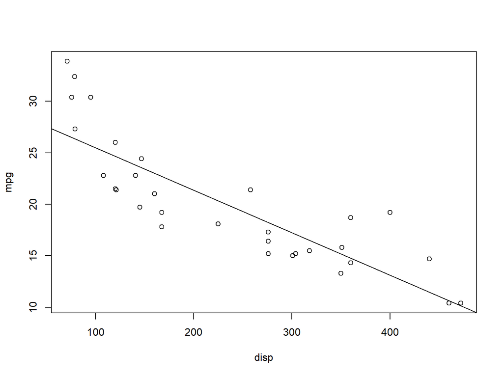

# Application Structure and link

Application is structured in a sidebar with the two combos to select the variables.

Anytime a variable is selected, reactively a new model is fitted and new output is calculated

If the same variable is selected for Y and X axis, no coefficients are calculated